# Installer survey - Section 2

Benoit Siberdt

2024-01-26

# Heat pump installer survey analysis

## Section 2 - The work installers do (Part I)

### Foreword

As for Section 1, throughout the analysis, we collapsed responses and respondents to the survey into various subcategories to get the most relevant information. This collapsing was done based on the guidelines laid out in the [analysis plan](https://docs.google.com/document/d/1M1nzdf3fyTjipmaKJKViin0EB3e3R1afOQglwMGJaII/edit).

You can find the pre-analysis code to run before analysing section 2 of the installer survey below.

OBQA: I prefer to use more code chunks in general.

OBQA: You don’t need to do this and, for large datasets, it will just detract from system memory

OBQA: I personally like to comment on the change in rows - in this case, 768 to 345. This indicates that there re a lot of partial responses.

OBQA: I tend to like to include checks when you make new variables, i.e., like a two-way table. Example below. It adds more lines to the script but I think is very important to check. It will throw up NAs for typos, for example.

```
##           employment_type The owner or co-owner of a firm An employee of a firm
##             Company owner                             163                     0
##  Contractor or freelancer                               0                     0
##                  Employee                               0                   112
##               Sole trader                              38                     0
##  A contractor or freelancer
##                           0
##                          32
##                           0
##                           0
```

```
##           employment_type Not asked I’m a sole trader
##             Company owner         0                 0
##  Contractor or freelancer        32                 0
##                  Employee       112                 0
##               Sole trader         0                38
##  I own a company with 5 or fewer employees I own a company with 6-25 employees
##                                        109                                  39
##                                          0                                   0
##                                          0                                   0
##                                          0                                   0
##  I own a company with 26-100 employees I own a company with over 100 employees
##                                     10                                       5
##                                      0                                       0
##                                      0                                       0
##                                      0                                       0
```

OBQA: Note the two lines above are identical, but using a pipe (second option) makes it easier to choose the variables as RStudio provides options for you.

```
##  employment_type_soletrader_owner_merged Company owner Contractor or freelancer
##                 Contractor or freelancer             0                       32
##                                 Employee             0                        0
##             Sole trader or company owner           163                        0
##  Employee Sole trader
##         0           0
##       112           0
##         0          38
```

```
##  employment_type_employee_contractor_merged Company owner
##                               Company owner           163
##           Contractor/freelancer or employee             0
##                                 Sole trader             0
##  Contractor or freelancer Employee Sole trader
##                         0        0           0
##                        32      112           0
##                         0        0          38
```

```
##              dummy_employment_type Company owner Contractor or freelancer
##       Company owner or sole trader           163                        0
##  Employee or contractor/freelancer             0                       32
##  Employee Sole trader
##         0          38
##       112           0
```

OBQA: I think a single variable could work here, but might be clear later on why you chose to use dummy variables.

```
## [1] "dummy_contractors"
```

```
## [1] "dummy_employees"
## [1] "dummy_soletraders"
## [1] "dummy_company_owner"
```

```
## [[1]]
##           employment_type   0  1
##             Company owner 163  0
##  Contractor or freelancer   0 32
##                  Employee 112  0
##               Sole trader  38  0
##
## [[2]]
##           employment_type   0   1
##             Company owner 163   0
##  Contractor or freelancer  32   0
##                  Employee   0 112
##               Sole trader  38   0
##
## [[3]]
##           employment_type   0
##             Company owner 163
##  Contractor or freelancer  32
##                  Employee 112
##               Sole trader  38
##
## [[4]]
##           employment_type   0   1
##             Company owner   0 163
##  Contractor or freelancer  32   0
##                  Employee 112   0
##               Sole trader  38   0
```

OBQA: As you can see, there is no 1 column for output 3, for sole traders. This is because there’s a typo above (should be “Sole trader)

```
##      age_collapsed Prefer not to say 18-24 25-34 35-44 45-54 55-64 65-74
##       34 and under                 0     7    48     0     0     0     0
##              35-44                 0     0     0   132     0     0     0
##              45-54                 0     0     0     0    83     0     0
##        55 and over                 0     0     0     0     0    59    12
##  Prefer not to say                 4     0     0     0     0     0     0
##  Over 75
##        0
##        0
##        0
##        0
##        0
```

```
##                     x4_how_long_have_you_been_working_with_heat_pumps
##               I don’t work with heat pumps and have no plans to do so
##  I don’t work with heat pumps, but plan to do so in the twelve months
##                                                            Don't know
##                                                   Less than 12 months
##                                                             1-3 years
##                                                             3-5 years
##                                                            5-10 years
##                                                           10-20 years
##                                                         Over 20 years
##  Don’t work with heat pumps Under 3 years 3-5 years 5-10 years Over 10 years
##                           0             0         0          0             0
##                           0             0         0          0             0
##                           0             0         0          0             0
##                           0            36         0          0             0
##                           0            91         0          0             0
##                           0             0        47          0             0
##                           0             0         0         59             0
##                           0             0         0          0            94
##                           0             0         0          0            18
```

```
##           x6a_what_size_company_do_you_own Sole trader Small Medium Large
##                                  Not asked           0     0      0     0
##                          I’m a sole trader          38     0      0     0
##  I own a company with 5 or fewer employees           0   109      0     0
##        I own a company with 6-25 employees           0     0     39     0
##      I own a company with 26-100 employees           0     0      0    10
##    I own a company with over 100 employees           0     0      0     5
##  Not asked
##        144
##          0
##          0
##          0
##          0
##          0
```

```
##           x6a_what_size_company_do_you_own Sole trader Small Medium and large
##                                  Not asked           0     0                0
##                          I’m a sole trader          38     0                0
##  I own a company with 5 or fewer employees           0   109                0
##        I own a company with 6-25 employees           0     0               39
##      I own a company with 26-100 employees           0     0               10
##    I own a company with over 100 employees           0     0                5
##  Not asked
##        144
##          0
##          0
##          0
##          0
##          0
```

```
##           x6b_what_size_company_do_you_work_for 5 or fewer 6-25 26-100 Over 100
##                                       Not asked          0    0      0        0
##                                      Don't know          0    0      0        0
##  I work for a company with 5 or fewer employees         10    0      0        0
##        I work for a company with 6-25 employees          0   55      0        0
##      I work for a company with 26-100 employees          0    0     22        0
##    I work for a company with over 100 employees          0    0      0       24
##  Not asked Don't know
##        233          0
##          0          1
##          0          0
##          0          0
##          0          0
##          0          0
```

```
##           x6b_what_size_company_do_you_work_for 25 or fewer Over 25 Not asked
##                                       Not asked           0       0       233
##                                      Don't know           0       0         0
##  I work for a company with 5 or fewer employees          10       0         0
##        I work for a company with 6-25 employees          55       0         0
##      I work for a company with 26-100 employees           0      22         0
##    I work for a company with over 100 employees           0      24         0
##  Don't know
##           0
##           1
##           0
##           0
##           0
##           0
```

```
##  x10_how_far_from_your_business_location_would_you_typically_travel_for_jobs_approximately
##                                                                                 Don't know
##                                                                         Less than 25 miles
##                                                                             25 to 50 miles
##                                                                            50 to 100 miles
##                                                                           100 to 200 miles
##                                                                           200 to 300 miles
##                                                                        More than 300 miles
##  Less than 25 miles 25-50 miles 50-100 miles Over 100 miles Don't know
##                   0           0            0              0          4
##                  91           0            0              0          0
##                   0         125            0              0          0
##                   0           0           69              0          0
##                   0           0            0             28          0
##                   0           0            0             12          0
##                   0           0            0             16          0
```

```
##  x12a_thinking_of_your_companys_overall_heating_work_what_does_it_currently_consist_of
##                                                                              Not asked
##                         Entirely commercial heating work, and no domestic heating work
##                         Mostly commercial heating work, and some domestic heating work
##                                 An even amount of domestic and commercial heating work
##                         Mostly domestic heating work, and some commercial heating work
##                         Entirely domestic heating work, and no commercial heating work
##  Mostly/entirely domestic Equal domestic/commercial Mostly/entirely commercial
##                         0                         0                          0
##                         0                         0                          1
##                         0                         0                          3
##                         0                        16                          0
##                        81                         0                          0
##                        62                         0                          0
##  Not asked
##        182
##          0
##          0
##          0
##          0
##          0
```

```
##  x12b_thinking_of_your_overall_heating_work_what_does_it_currently_consist_of
##                                                                     Not asked
##                Entirely commercial heating work, and no domestic heating work
##                Mostly commercial heating work, and some domestic heating work
##                        An even amount of domestic and commercial heating work
##                Mostly domestic heating work, and some commercial heating work
##                Entirely domestic heating work, and no commercial heating work
##  Mostly/entirely domestic Equal domestic/commercial Mostly/entirely commercial
##                       143                        16                          4
##                         0                         0                          0
##                         0                         0                          0
##                         0                         0                          0
##                         0                         0                          0
##                         0                         0                          0
##  Not asked
##          0
##          1
##          4
##          8
##         87
##         82
```

```
##  x13a_thinking_of_your_companys_overall_heating_work_in_12_months_time_what_do_you_intend_it_to_consist_of
##                                                                                                  Not asked
##                                             Entirely commercial heating work, and no domestic heating work
##                                             Mostly commercial heating work, and some domestic heating work
##                                                     An even amount of domestic and commercial heating work
##                                             Mostly domestic heating work, and some commercial heating work
##                                             Entirely domestic heating work, and no commercial heating work
##  Mostly/entirely domestic Equal domestic/commercial Mostly/entirely commercial
##                         0                         0                          0
##                         0                         0                          0
##                         0                         0                          4
##                         0                        22                          0
##                        90                         0                          0
##                        47                         0                          0
##  Not asked
##        182
##          0
##          0
##          0
##          0
##          0
```

```
##  x13b_thinking_of_your_overall_heating_work_in_12_months_time_what_do_you_intend_it_to_consist_of
##                                                                                         Not asked
##                                    Entirely commercial heating work, and no domestic heating work
##                                    Mostly commercial heating work, and some domestic heating work
##                                            An even amount of domestic and commercial heating work
##                                    Mostly domestic heating work, and some commercial heating work
##                                    Entirely domestic heating work, and no commercial heating work
##  Mostly/entirely domestic Equal domestic/commercial Mostly/entirely commercial
##                         0                         0                          0
##                         0                         0                          1
##                         0                         0                          5
##                         0                        12                          0
##                        93                         0                          0
##                        71                         0                          0
##  Not asked
##        163
##          0
##          0
##          0
##          0
##          0
```

```
##            x14a_thinking_of_the_heating_systems_your_company_installs_do_you_work_on
##                                                                            Not asked
##                                                                      Only heat pumps
##                                            Mostly heat pumps, and some other systems
##                                      An equal number of heat pumps and other systems
##                                            Mostly other systems, and some heat pumps
##                           Almost entirely other systems and the occasional heat pump
##  My company doesn't install any heat pumps, but plans to do so in the next 12 months
##                 My company doesn't install any heat pumps, and has no plans to do so
##  Mostly heat pumps Equal split Mostly non-heat pumps Don’t install heat pumps
##                  0           0                     0                        0
##                 31           0                     0                        0
##                 53           0                     0                        0
##                  0          25                     0                        0
##                  0           0                    32                        0
##                  0           0                    15                        0
##                  0           0                     0                        5
##                  0           0                     0                        2
##  Not asked
##        182
##          0
##          0
##          0
##          0
##          0
##          0
##          0
```

```
##            x14b_thinking_of_the_heating_systems_you_install_do_you_work_on
##                                                                  Not asked
##                                                            Only heat pumps
##                                  Mostly heat pumps, and some other systems
##                            An equal number of heat pumps and other systems
##                                  Mostly other systems, and some heat pumps
##                Almost entirely other systems, and the occasional heat pump
##  I don't install any heat pumps, but I plan to do so in the next 12 months
##                  I don't install any heat pumps and have no plans to do so
##  Mostly heat pumps Equal split Mostly non-heat pumps Don’t install heat pumps
##                  0           0                     0                        0
##                 49           0                     0                        0
##                 54           0                     0                        0
##                  0          19                     0                        0
##                  0           0                    34                        0
##                  0           0                    19                        0
##                  0           0                     0                        6
##                  0           0                     0                        1
##  Not asked
##        163
##          0
##          0
##          0
##          0
##          0
##          0
##          0
```

#### 2.01 | What proportion of survey participants’ current work is domestic or commercial?

Table and Figure 2.1a to 2.1c show the distribution of domestic vs commercial heating work across the different categories of installers (employment types). In the survey, company owners and the remaining three categories of installers were asked slightly different questions (although same choices). Therefore Table and Figure 2.1a shows the distribution for company owners, while Table and Figure 2.1.b provide the distribution for sole traders, employees, and contractors.

Table 2.1a. Type of heating work (company owners)

| Heating work | Frequency |
| --- | --- |
| Entirely commercial heating work, and no domestic heating work | 1 |
| Mostly commercial heating work, and some domestic heating work | 3 |
| An even amount of domestic and commercial heating work | 16 |
| Mostly domestic heating work, and some commercial heating work | 81 |
| Entirely domestic heating work, and no commercial heating work | 62 |

OBQA: I think you could use a function here to make this much more straightforward. I’ve suggested one below.

Table 2.1a. Type of heating work (company owners) (n = 163)

| Heating work | Frequency |
| --- | --- |
| Entirely commercial heating work, and no domestic heating work | 1 |
| Mostly commercial heating work, and some domestic heating work | 3 |
| An even amount of domestic and commercial heating work | 16 |
| Mostly domestic heating work, and some commercial heating work | 81 |
| Entirely domestic heating work, and no commercial heating work | 62 |

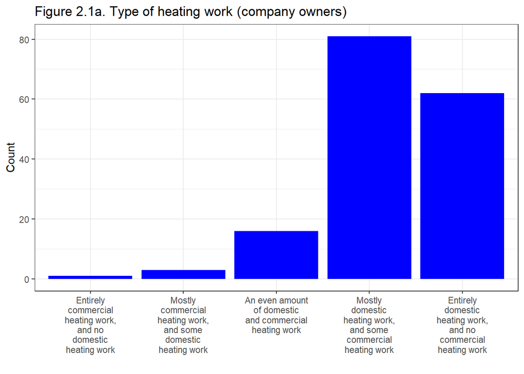

OBQA: Similarly, no need to create data_filtered - you can jut use a pipe.

Example function below.

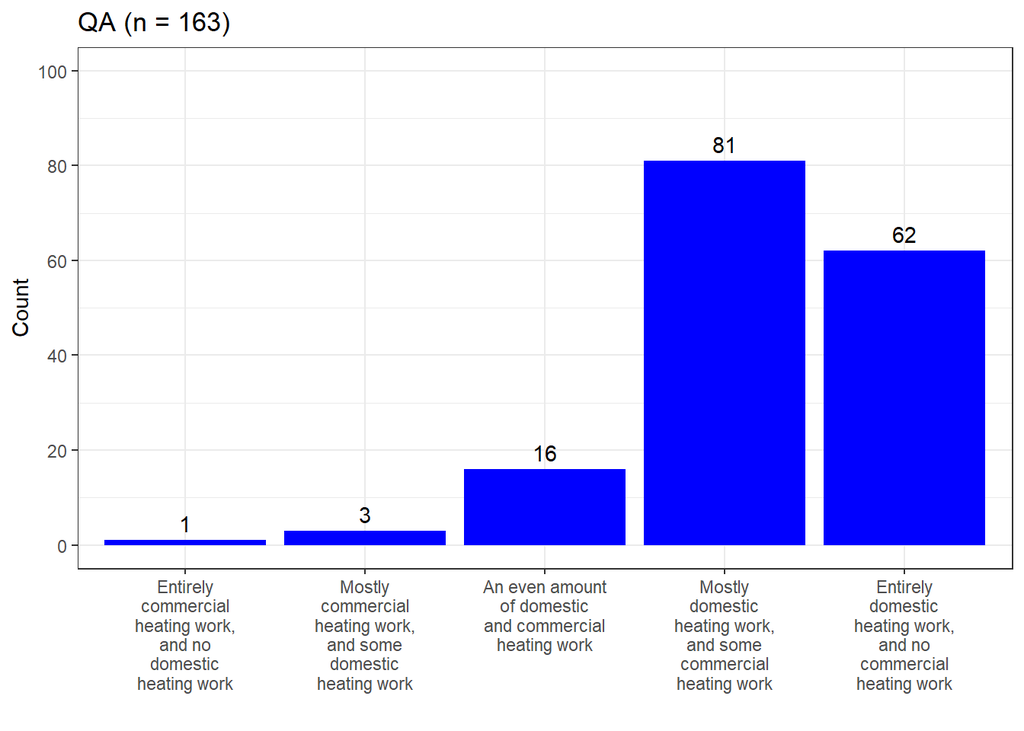

Table 2.1b. Type of heating work (sole traders, employees, contractors)

| Heating work | Frequency |
| --- | --- |
| Entirely commercial heating work, and no domestic heating work | 1 |
| Mostly commercial heating work, and some domestic heating work | 4 |
| An even amount of domestic and commercial heating work | 8 |
| Mostly domestic heating work, and some commercial heating work | 87 |
| Entirely domestic heating work, and no commercial heating work | 82 |

QA (n = 182)

| Heating work | Frequency |
| --- | --- |
| Entirely commercial heating work, and no domestic heating work | 1 |
| Mostly commercial heating work, and some domestic heating work | 4 |
| An even amount of domestic and commercial heating work | 8 |
| Mostly domestic heating work, and some commercial heating work | 87 |
| Entirely domestic heating work, and no commercial heating work | 82 |

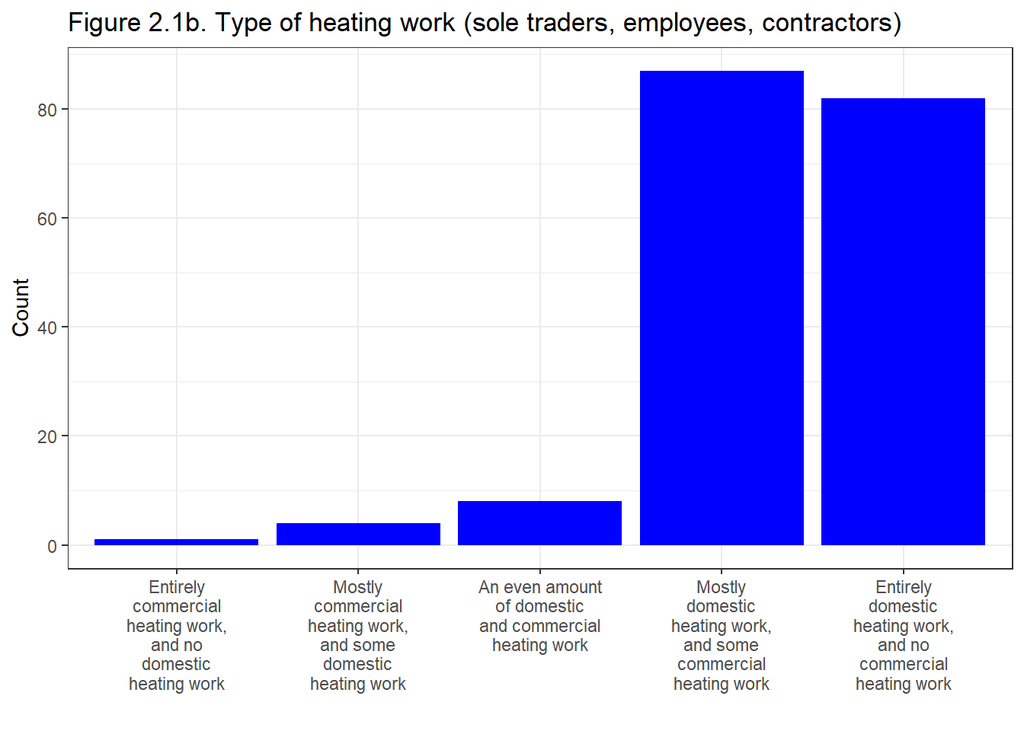

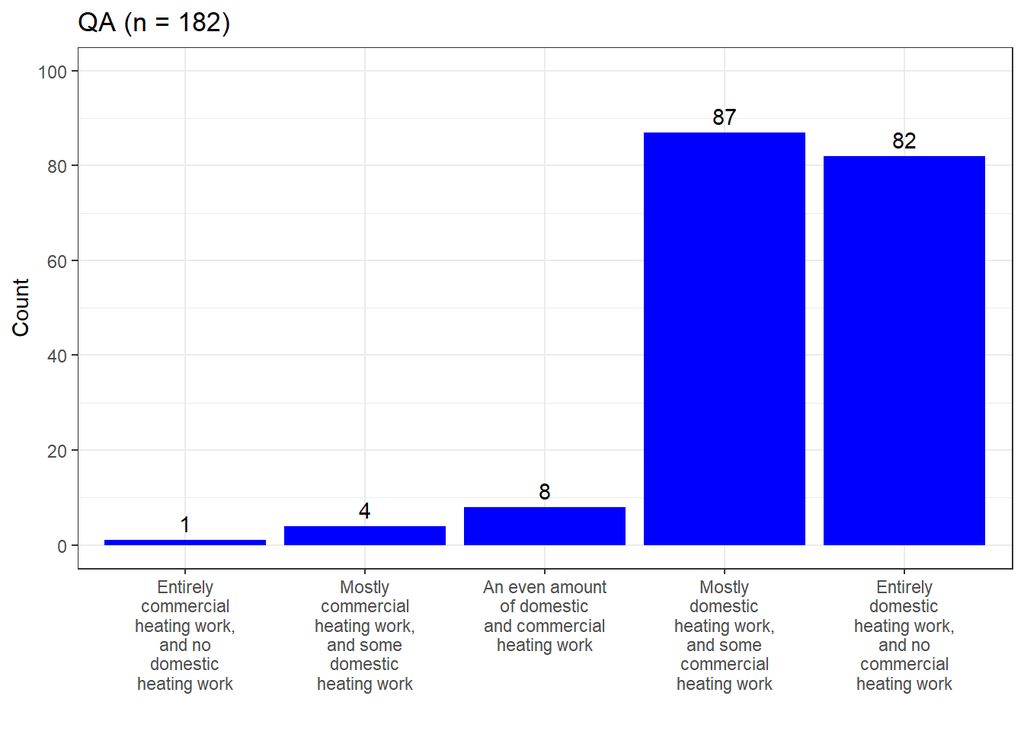

In the survey, company owners were asked question 12a, while sole traders, employees, and contractors were asked question 12b. The difference across these two questions lies in the slightly different formulation (asking about the company’s work vs the individual’s work). Given that answers were the same, Table and Figure 2.1c provide the distribution for all categories of installers together to give the overall distribution of survey respondents.

```
##  x12b_thinking_of_your_overall_heating_work_what_does_it_currently_consist_of
##                                                                     Not asked
##                Entirely commercial heating work, and no domestic heating work
##                Mostly commercial heating work, and some domestic heating work
##                        An even amount of domestic and commercial heating work
##                Mostly domestic heating work, and some commercial heating work
##                Entirely domestic heating work, and no commercial heating work
##  Not asked Entirely commercial heating work, and no domestic heating work
##          0                                                              1
##          1                                                              0
##          4                                                              0
##          8                                                              0
##         87                                                              0
##         82                                                              0
##  Mostly commercial heating work, and some domestic heating work
##                                                               3
##                                                               0
##                                                               0
##                                                               0
##                                                               0
##                                                               0
##  An even amount of domestic and commercial heating work
##                                                      16
##                                                       0
##                                                       0
##                                                       0
##                                                       0
##                                                       0
##  Mostly domestic heating work, and some commercial heating work
##                                                              81
##                                                               0
##                                                               0
##                                                               0
##                                                               0
##                                                               0
##  Entirely domestic heating work, and no commercial heating work
##                                                              62
##                                                               0
##                                                               0
##                                                               0
##                                                               0
##                                                               0
```

Table 2.1c. Type of heating work (all installers)

| Heating work | Frequency |
| --- | --- |
| Entirely commercial heating work, and no domestic heating work | 2 |
| Mostly commercial heating work, and some domestic heating work | 7 |
| An even amount of domestic and commercial heating work | 24 |
| Mostly domestic heating work, and some commercial heating work | 168 |
| Entirely domestic heating work, and no commercial heating work | 144 |

OBQA: Looks fine

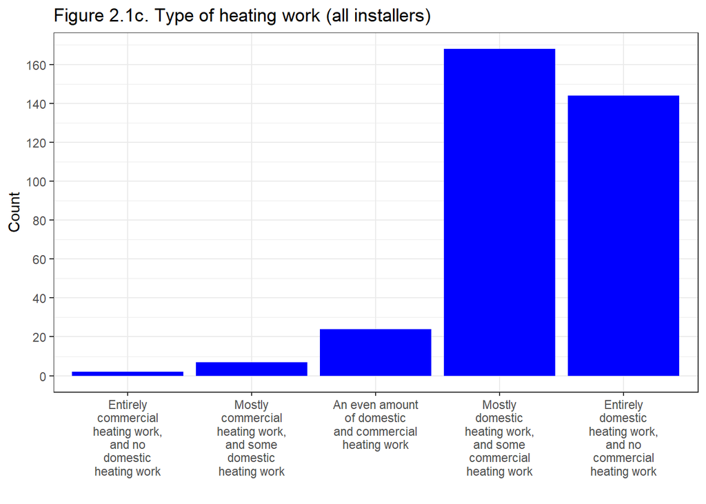

OBQA: Looks fine

#### 2.02 | What proportion of survey participants’ planned future work will be domestic or commercial?

The following tables and figures show the distribution for the projection in the next 12 months of the ratio between domestic and commercial work. Given that the structure of the survey is identical to the previous question the same note applies. Therefore Tables and Figures 2.2a to 2.2c show the distribution for different groups of respondents: company owners only; employees, sole traders, and contractors; and all installers.

Table 2.2a. Type of heating work in the next 12 months (company owners)

| Heating work | Frequency |
| --- | --- |
| Entirely commercial heating work, and no domestic heating work | 0 |
| Mostly commercial heating work, and some domestic heating work | 4 |
| An even amount of domestic and commercial heating work | 22 |
| Mostly domestic heating work, and some commercial heating work | 90 |
| Entirely domestic heating work, and no commercial heating work | 47 |

QA (n = 163)

| QA | QA |
| --- | --- |
| Entirely commercial heating work, and no domestic heating work | 0 |
| Mostly commercial heating work, and some domestic heating work | 4 |
| An even amount of domestic and commercial heating work | 22 |
| Mostly domestic heating work, and some commercial heating work | 90 |
| Entirely domestic heating work, and no commercial heating work | 47 |

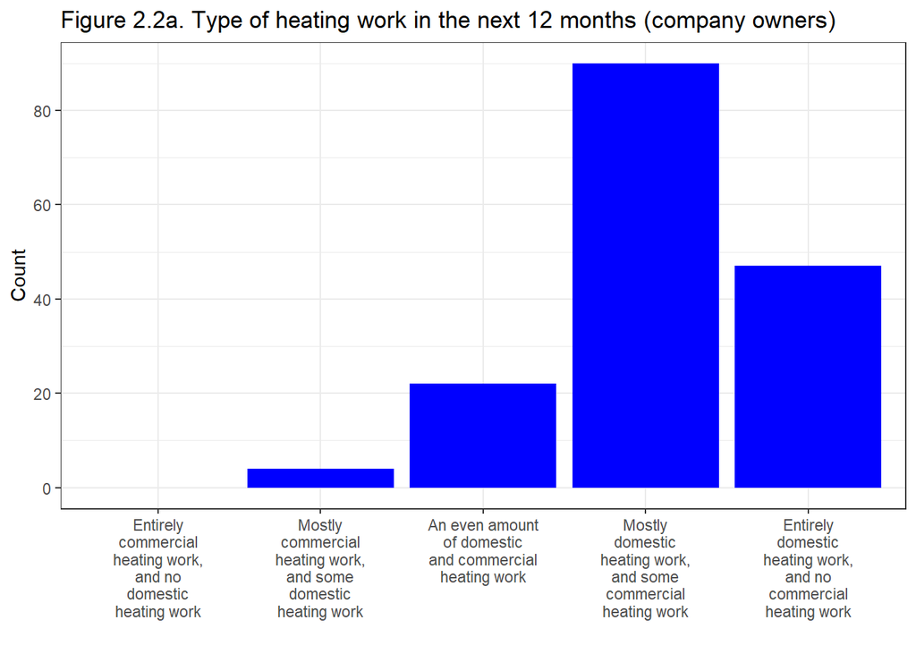

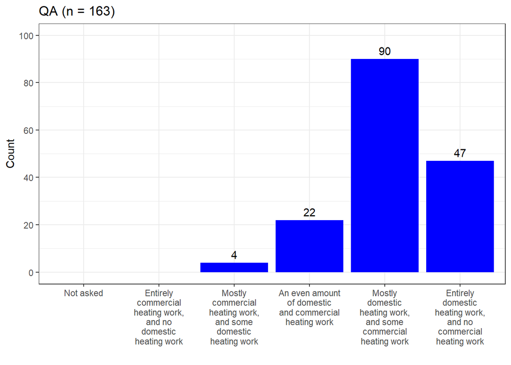

Table 2.2b. Type of heating work in the next 12 months (sole traders, employees, contractors)

| Heating work | Frequency |
| --- | --- |
| Entirely commercial heating work, and no domestic heating work | 1 |
| Mostly commercial heating work, and some domestic heating work | 5 |
| An even amount of domestic and commercial heating work | 12 |
| Mostly domestic heating work, and some commercial heating work | 93 |
| Entirely domestic heating work, and no commercial heating work | 71 |

QA (n = 182)

| QA | QA |
| --- | --- |
| Entirely commercial heating work, and no domestic heating work | 1 |
| Mostly commercial heating work, and some domestic heating work | 5 |
| An even amount of domestic and commercial heating work | 12 |
| Mostly domestic heating work, and some commercial heating work | 93 |
| Entirely domestic heating work, and no commercial heating work | 71 |

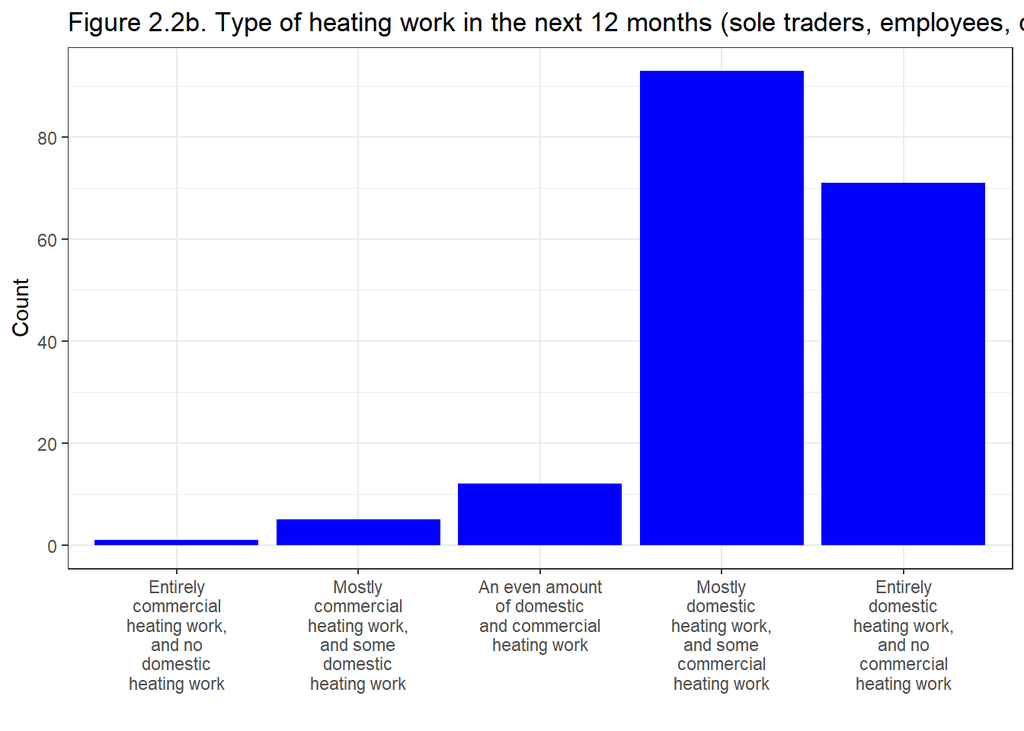

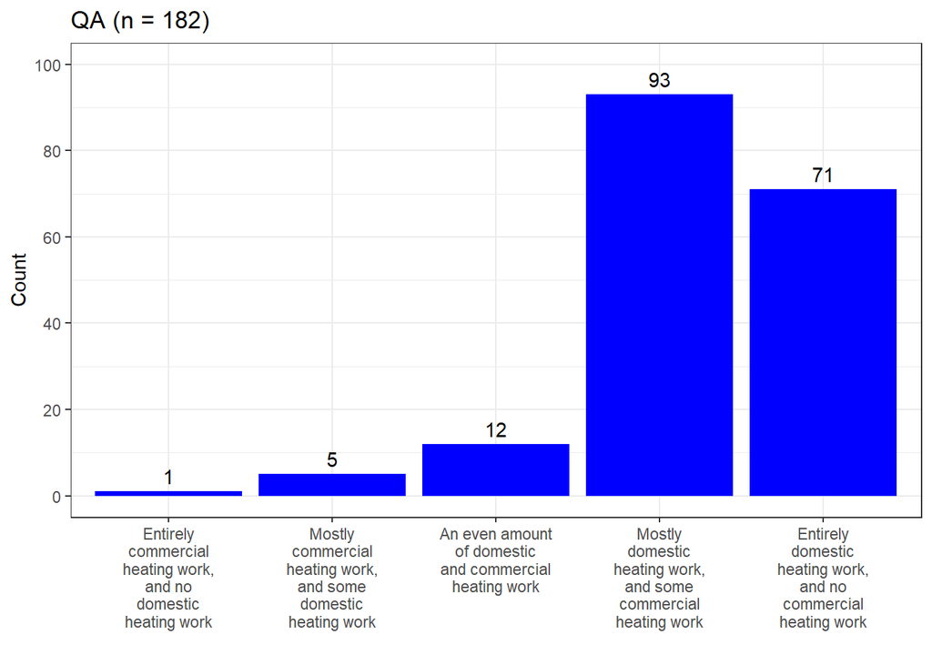

Table 2.2c. Type of heating work in the next 12 months (all installers)

| Heating work | Frequency |
| --- | --- |
| Entirely commercial heating work, and no domestic heating work | 1 |
| Mostly commercial heating work, and some domestic heating work | 9 |
| An even amount of domestic and commercial heating work | 34 |
| Mostly domestic heating work, and some commercial heating work | 183 |
| Entirely domestic heating work, and no commercial heating work | 118 |

OBQA: Looks fine

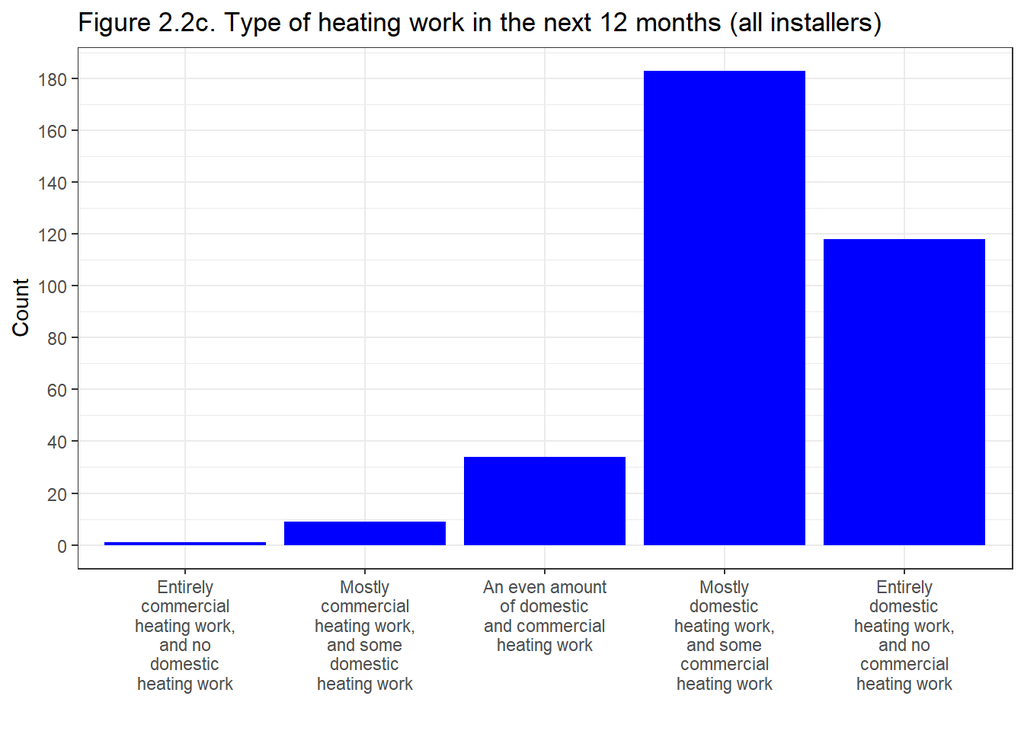

OBQA: Looks fine

#### 2.03 | Are survey participants planning to change the proportion of their domestic or commercial heating work?

[output not shown]

[figure not shown]

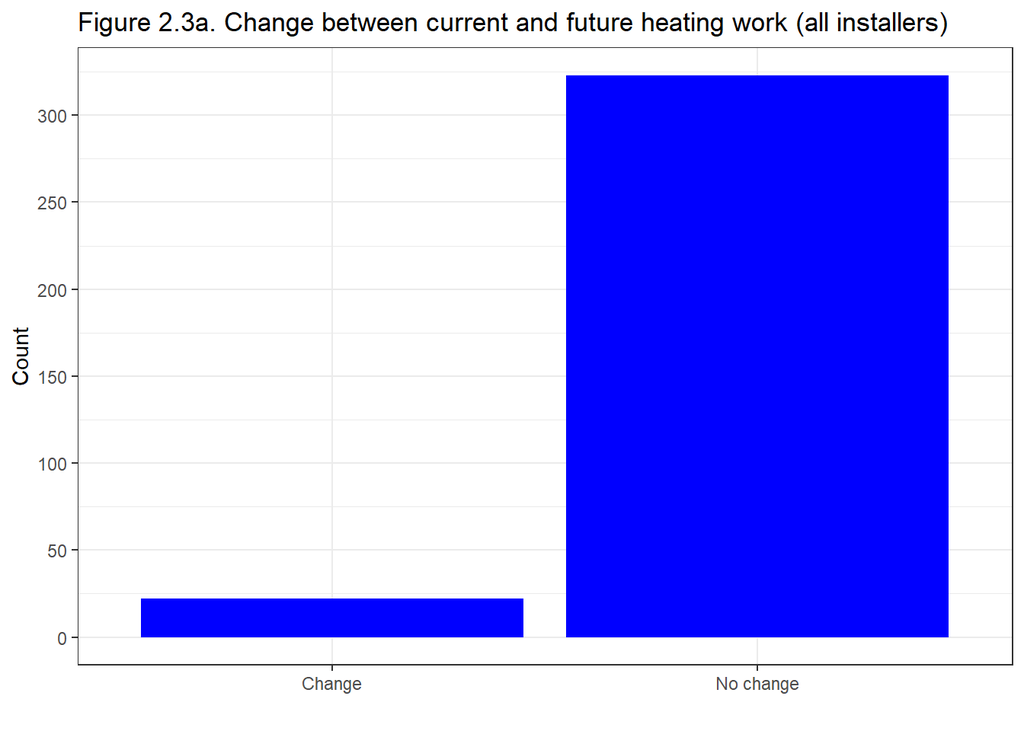

OBQA: Makes sense.

A Sankey digram might be nice here

```
## Links is a tbl_df. Converting to a plain data frame.
```

[interactive chart not shown]

For the installers who indicated that they will change their ratio of heating work, we also want to know what the change is. Table 2.3b show the distribution of change patterns of change installers’ current ratio of commercial and domestic heating work.

Table 2.3b. Patterns of change from current to future heating work (all installers)

| Current heating work | Future heating work | Count |
| --- | --- | --- |
| Mostly/entirely domestic | Equal domestic/commercial | 15 |
| Equal domestic/commercial | Mostly/entirely domestic | 2 |
| Equal domestic/commercial | Mostly/entirely commercial | 3 |
| Mostly/entirely commercial | Mostly/entirely domestic | 2 |

```
##  x12c_all_installers_collapsed Mostly/entirely domestic
##       Mostly/entirely domestic                        0
##      Equal domestic/commercial                        2
##     Mostly/entirely commercial                        2
##  Equal domestic/commercial Mostly/entirely commercial
##                         15                          0
##                          0                          3
##                          0                          0
```

#### 2.04 | How do planned changes to the proportion of survey participants’ domestic or commercial heating work differ depending on the size of the company they work for or own?

Next, we want to know whether these patterns of change overlap with specific categories of installers or company size. Table 2.4a provides the distribution by employment type for installers who indicated they will change their ratio of heating work in the next 12 months.

Table 2.4a. Patterns of change from current to future heating work by occupation type

| Employment type | Current heating work | Future heating work | Count |
| --- | --- | --- | --- |
| Company owner | Mostly/entirely domestic | Equal domestic/commercial | 9 |
| Company owner | Equal domestic/commercial | Mostly/entirely domestic | 1 |
| Company owner | Equal domestic/commercial | Mostly/entirely commercial | 2 |
| Company owner | Mostly/entirely commercial | Mostly/entirely domestic | 2 |
| Employee | Mostly/entirely domestic | Equal domestic/commercial | 6 |
| Employee | Equal domestic/commercial | Mostly/entirely domestic | 1 |
| Employee | Equal domestic/commercial | Mostly/entirely commercial | 1 |

```
## $`Company owner`
##  x12c_all_installers_collapsed Mostly/entirely domestic
##       Mostly/entirely domestic                        0
##      Equal domestic/commercial                        1
##     Mostly/entirely commercial                        2
##  Equal domestic/commercial Mostly/entirely commercial
##                          9                          0
##                          0                          2
##                          0                          0
##
## $Employee
##  x12c_all_installers_collapsed Mostly/entirely domestic
##       Mostly/entirely domestic                        0
##      Equal domestic/commercial                        1
##     Mostly/entirely commercial                        0
##  Equal domestic/commercial Mostly/entirely commercial
##                          6                          0
##                          0                          1
##                          0                          0
```

Table 2.4b provides the distribution by company size for employees.

Table 2.4b. Patterns of change from current to future heating work by company size (employees)

| Company size | Current heating work | Future heating work | Count |
| --- | --- | --- | --- |
| 6-25 | Mostly/entirely domestic | Equal domestic/commercial | 3 |
| 6-25 | Equal domestic/commercial | Mostly/entirely domestic | 1 |
| 6-25 | Equal domestic/commercial | Mostly/entirely commercial | 1 |
| 26-100 | Mostly/entirely domestic | Equal domestic/commercial | 2 |
| Over 100 | Mostly/entirely domestic | Equal domestic/commercial | 1 |

```
## $`6-25`
##  x12c_all_installers_collapsed Mostly/entirely domestic
##       Mostly/entirely domestic                        0
##      Equal domestic/commercial                        1
##     Mostly/entirely commercial                        0
##  Equal domestic/commercial Mostly/entirely commercial
##                          3                          0
##                          0                          1
##                          0                          0
##
## $`26-100`
##  x12c_all_installers_collapsed Mostly/entirely domestic
##       Mostly/entirely domestic                        0
##      Equal domestic/commercial                        0
##     Mostly/entirely commercial                        0
##  Equal domestic/commercial Mostly/entirely commercial
##                          2                          0
##                          0                          0
##                          0                          0
##
## $`Over 100`
##  x12c_all_installers_collapsed Mostly/entirely domestic
##       Mostly/entirely domestic                        0
##      Equal domestic/commercial                        0
##     Mostly/entirely commercial                        0
##  Equal domestic/commercial Mostly/entirely commercial
##                          1                          0
##                          0                          0
##                          0                          0
##
## $`Not asked`
##  x12c_all_installers_collapsed Mostly/entirely domestic
##       Mostly/entirely domestic                        0
##      Equal domestic/commercial                        1
##     Mostly/entirely commercial                        2
##  Equal domestic/commercial Mostly/entirely commercial
##                          9                          0
##                          0                          2
##                          0                          0
```

[output not shown]

#### 2.06 | Of the systems that survey participants install, what proportion are heat pumps?

Table and Figure 2.6a show the distribution of heating systems installations across the different categories of installers.

Table 2.6a. Distribution of the different heating systems installations (all installers)

| Type of heating systems | Frequency |
| --- | --- |
| Only heat pumps | 80 |
| Mostly heat pumps, and some other systems | 107 |
| An equal number of heat pumps and other systems | 44 |
| Mostly other systems, and some heat pumps | 66 |
| Almost entirely other systems, and the occasional heat pump | 34 |
| My company doesn’t/I don’t install any heat pumps, but plan(s) to do so in the next 12 months | 11 |
| My company doesn’t/I don’t install any heat pumps, and has/have no plans to do so | 3 |

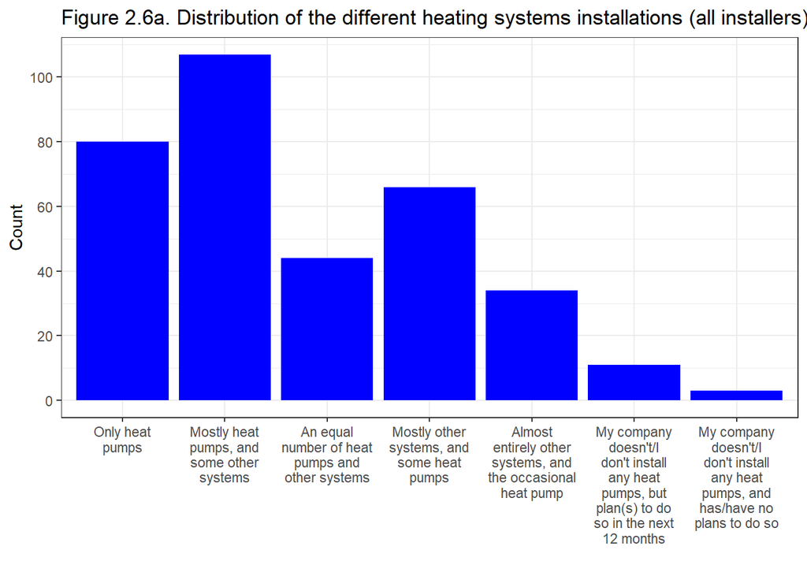

Next, we want to know whether different types of installers display different patterns. Table and Figure 2.6b show the distribution by employment type: sole traders, company owners, employees, and contractors.

Table 2.6b. Distribution of the different heating systems installations by employment type

|  | Only heat pumps | Mostly heat pumps, and some other systems | An equal number of heat pumps and other systems | Mostly other systems, and some heat pumps | Almost entirely other systems, and the occasional heat pump | Don’t but plan to do so in the next 12 months | Don’t and have no plans to do so |
| --- | --- | --- | --- | --- | --- | --- | --- |
| Company owner | 31 | 53 | 25 | 32 | 15 | 5 | 2 |
| Contractor or freelancer | 9 | 11 | 1 | 4 | 5 | 2 | 0 |
| Employee | 39 | 38 | 10 | 17 | 6 | 2 | 0 |
| Sole trader | 1 | 5 | 8 | 13 | 8 | 2 | 1 |

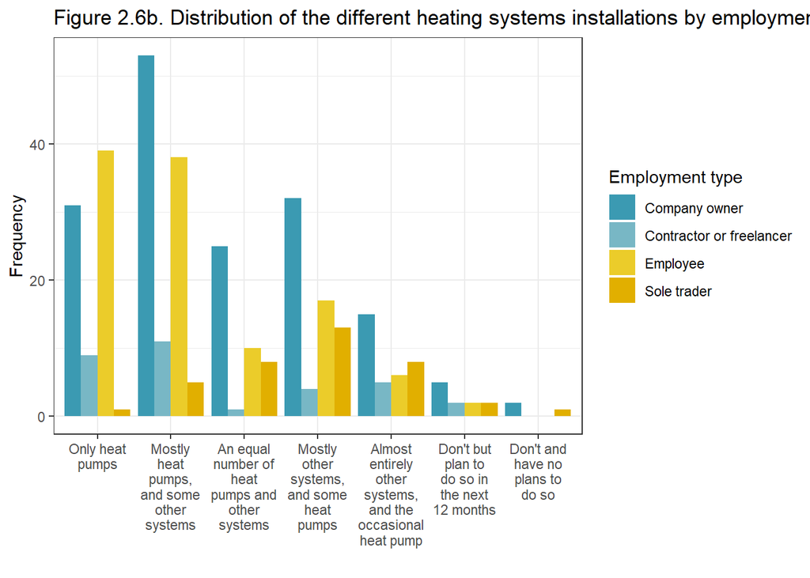

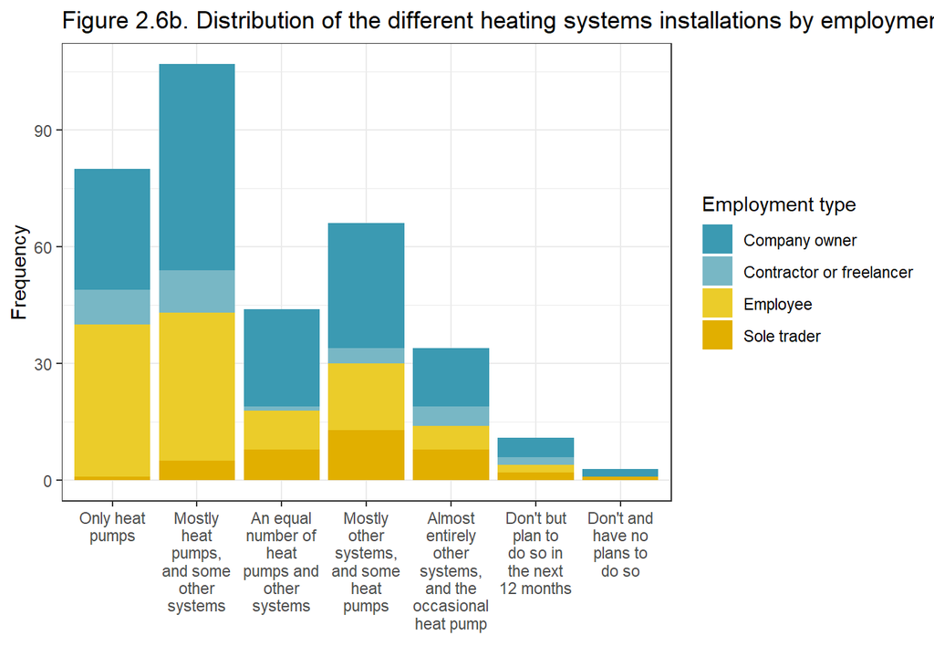

Table and Figure 2.6c provide the distribution for a binary classification of employment type.

|  | Only heat pumps | Mostly heat pumps, and some other systems | An equal number of heat pumps and other systems | Mostly other systems, and some heat pumps | Almost entirely other systems, and the occasional heat pump | Don’t but plan to do so in the next 12 months | Don’t and have no plans to do so |
| --- | --- | --- | --- | --- | --- | --- | --- |
| Company owner or sole trader | 32 | 58 | 33 | 45 | 23 | 7 | 3 |
| Employee or contractor/freelancer | 48 | 49 | 11 | 21 | 11 | 4 | 0 |

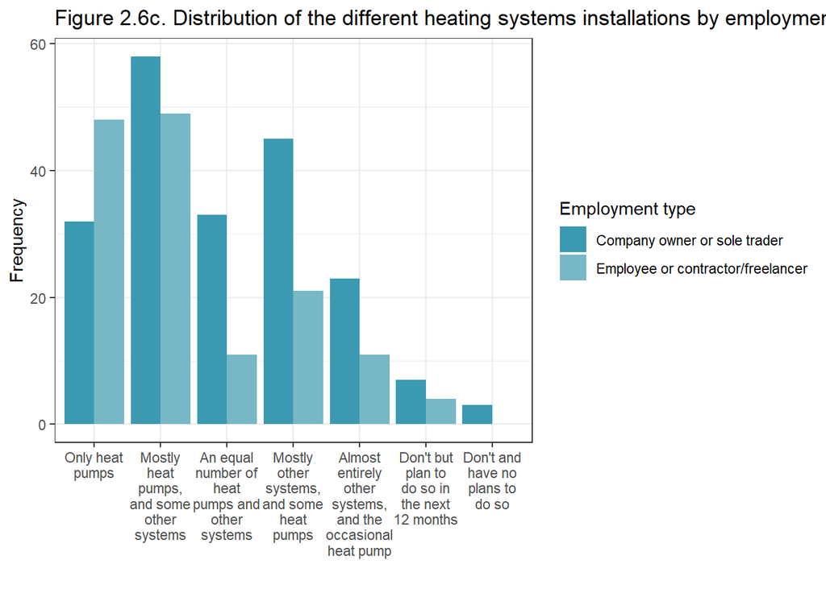

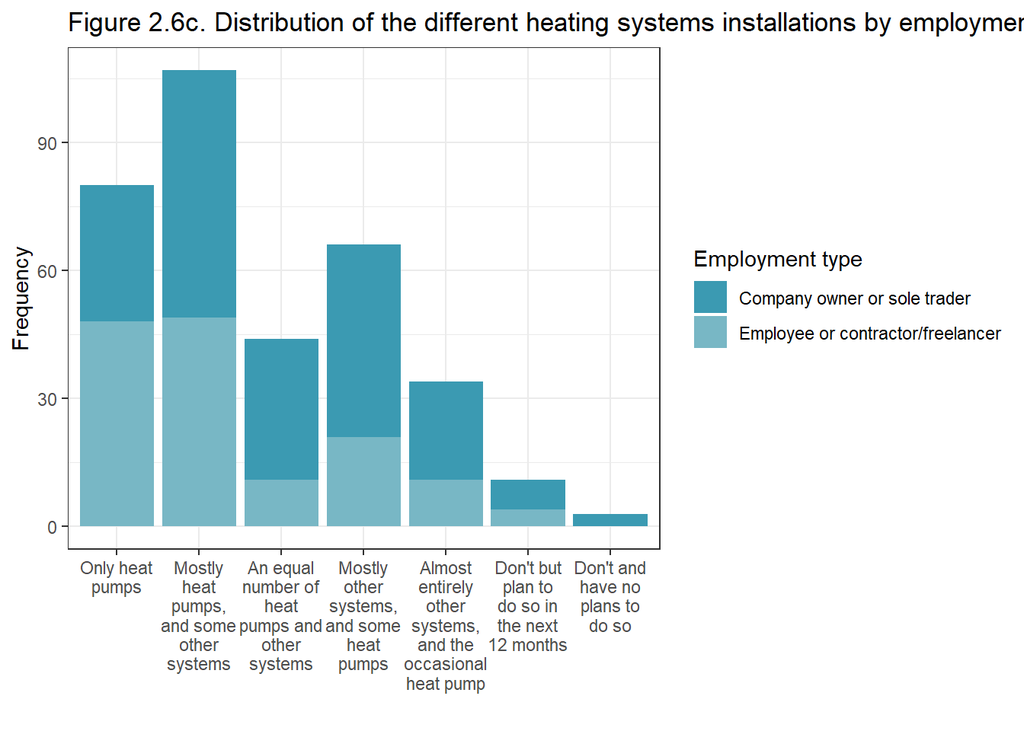

Lastly, the following tables and figures provide the distribution for an alternative classification of heating system installations (more aggregated). The approach is the same as above: first all installers, then by employment type, lastly by binary employment type. Table and Figure 2.6d show the distribution of heating systems installations across the different categories of installers.

Table 2.6d. Distribution of the different heating systems installations (all installers)

| Type of heating systems | Frequency |
| --- | --- |
| Mostly heat pumps | 187 |
| Equal split | 44 |
| Mostly non-heat pumps | 100 |
| Don’t install heat pumps | 14 |

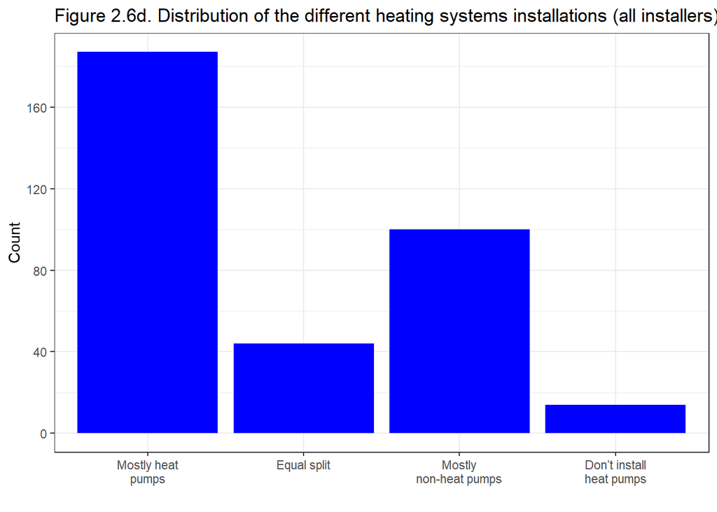

Table and Figure 2.6e show the distribution by employment type: sole traders, company owners, employees, and contractors.

Table 2.6e. Distribution of the different heating systems installations by employment type

|  | Mostly heat pumps | Equal split | Mostly non-heat pumps | Don’t install heat pumps |
| --- | --- | --- | --- | --- |
| Company owner | 84 | 25 | 47 | 7 |
| Contractor or freelancer | 20 | 1 | 9 | 2 |
| Employee | 77 | 10 | 23 | 2 |
| Sole trader | 6 | 8 | 21 | 3 |

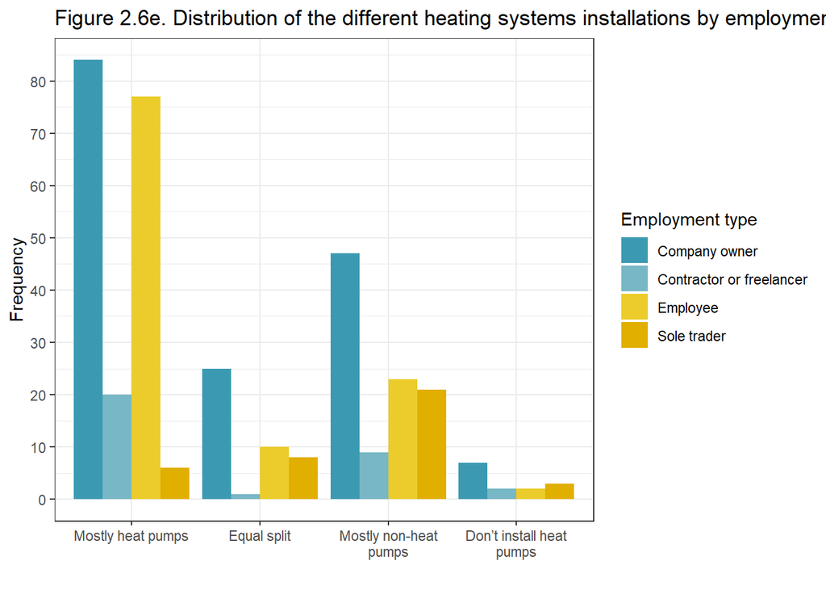

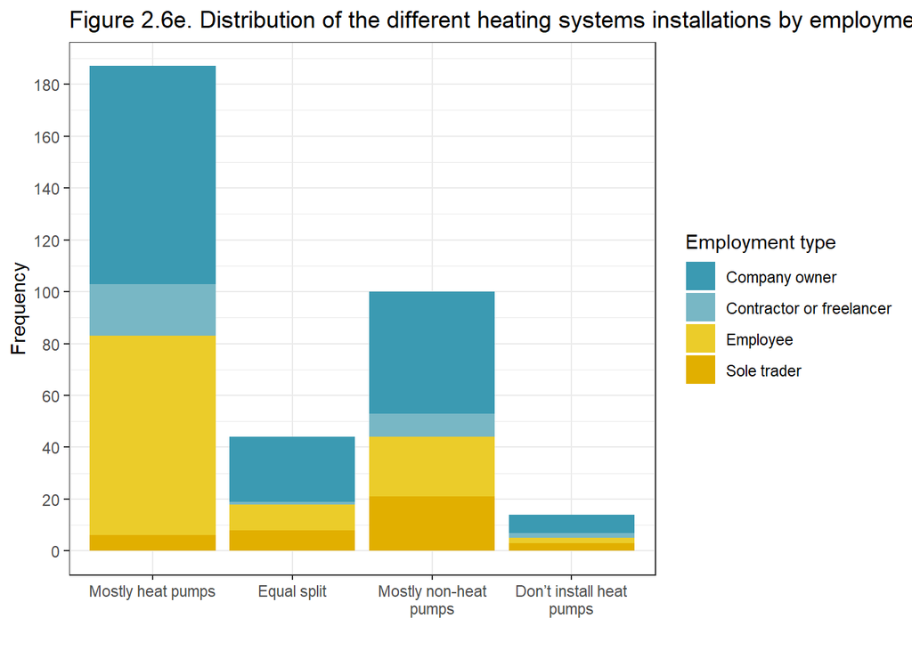

Table and Figure 2.6f provide the distribution for a binary classification of employment type.

|  | Mostly heat pumps | Equal split | Mostly non-heat pumps | Don’t install heat pumps |
| --- | --- | --- | --- | --- |
| Company owner or sole trader | 90 | 33 | 68 | 10 |
| Employee or contractor/freelancer | 97 | 11 | 32 | 4 |

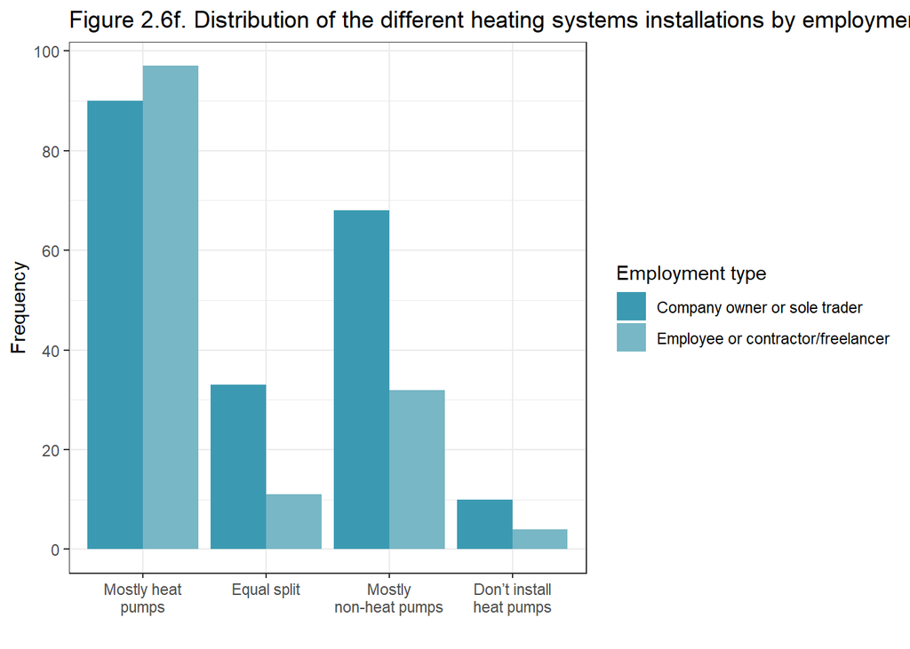

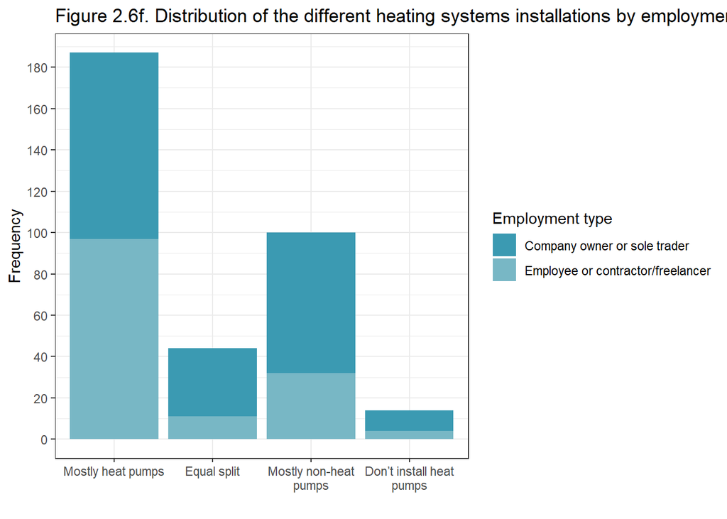

#### 2.07 | Of the systems that survey participants service and maintain, what proportion are heat pumps?

We also want to know about the heating systems that installers service and maintain. It could that many only install heat pump but spend a large share of the week servicing gas boilers. Table and Figure 2.7a show the distribution for all installers.

Table 2.7a. Distribution of the different heating systems service and maintenance (all installers)

| Type of heating systems | Frequency |
| --- | --- |
| Only heat pumps | 85 |
| Mostly heat pumps, and some other systems | 81 |
| An equal number of heat pumps and other systems | 35 |
| Mostly other systems, and some heat pumps | 67 |
| Almost entirely other systems, and the occasional heat pump | 36 |
| My company doesn’t/I don’t service and maintain any heat pumps, but plan(s) to do so in the next 12 months | 24 |
| My company doesn’t/I don’t service and maintain any heat pumps, and has/have no plans to do so | 17 |

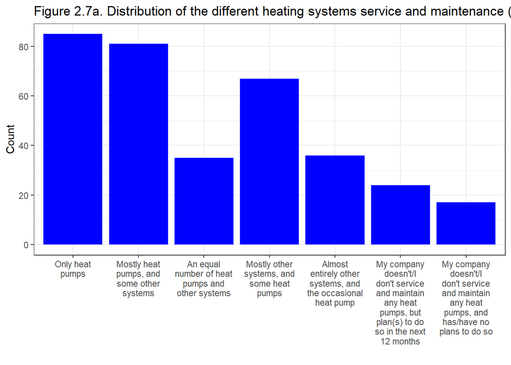

Table and Figure 2.7b show the distribution by employment type: sole traders, company owners, employees, and contractors.

Table 2.7b. Distribution of the different heating systems service and maintenance by employment type

|  | Only heat pumps | Mostly heat pumps, and some other systems | An equal number of heat pumps and other systems | Mostly other systems, and some heat pumps | Almost entirely other systems, and the occasional heat pump | Don’t but plan to do so in the next 12 months | Don’t and have no plans to do so |
| --- | --- | --- | --- | --- | --- | --- | --- |
| Company owner | 33 | 41 | 21 | 36 | 14 | 12 | 6 |
| Contractor or freelancer | 7 | 6 | 2 | 5 | 4 | 4 | 4 |
| Employee | 45 | 27 | 9 | 14 | 9 | 3 | 5 |
| Sole trader | 0 | 7 | 3 | 12 | 9 | 5 | 2 |

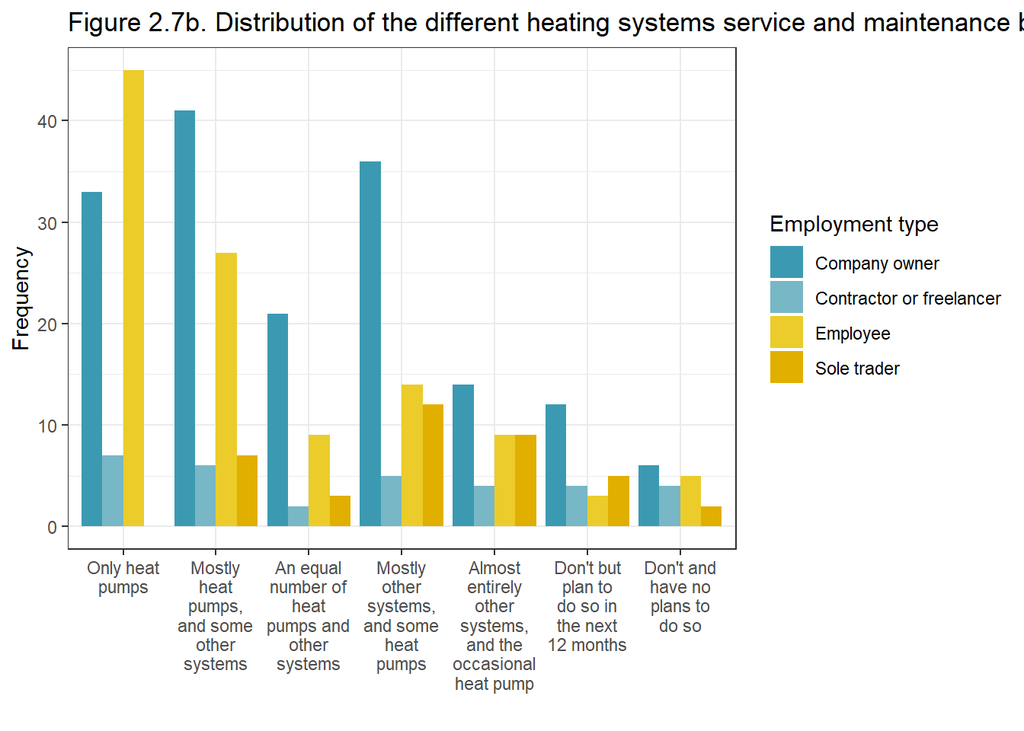

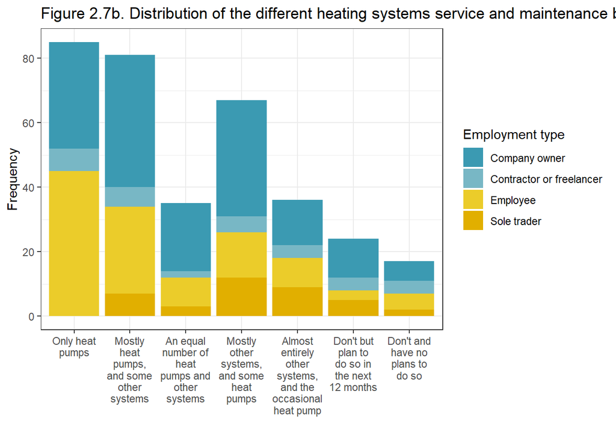

Table and Figure 2.7c provide the distribution for a binary classification of employment type.

Table 2.7c. Distribution of the different heating systems service and maintenance by employment type

|  | Only heat pumps | Mostly heat pumps, and some other systems | An equal number of heat pumps and other systems | Mostly other systems, and some heat pumps | Almost entirely other systems, and the occasional heat pump | Don’t but plan to do so in the next 12 months | Don’t and have no plans to do so |
| --- | --- | --- | --- | --- | --- | --- | --- |
| Company owner or sole trader | 33 | 48 | 24 | 48 | 23 | 17 | 8 |
| Employee or contractor/freelancer | 52 | 33 | 11 | 19 | 13 | 7 | 9 |

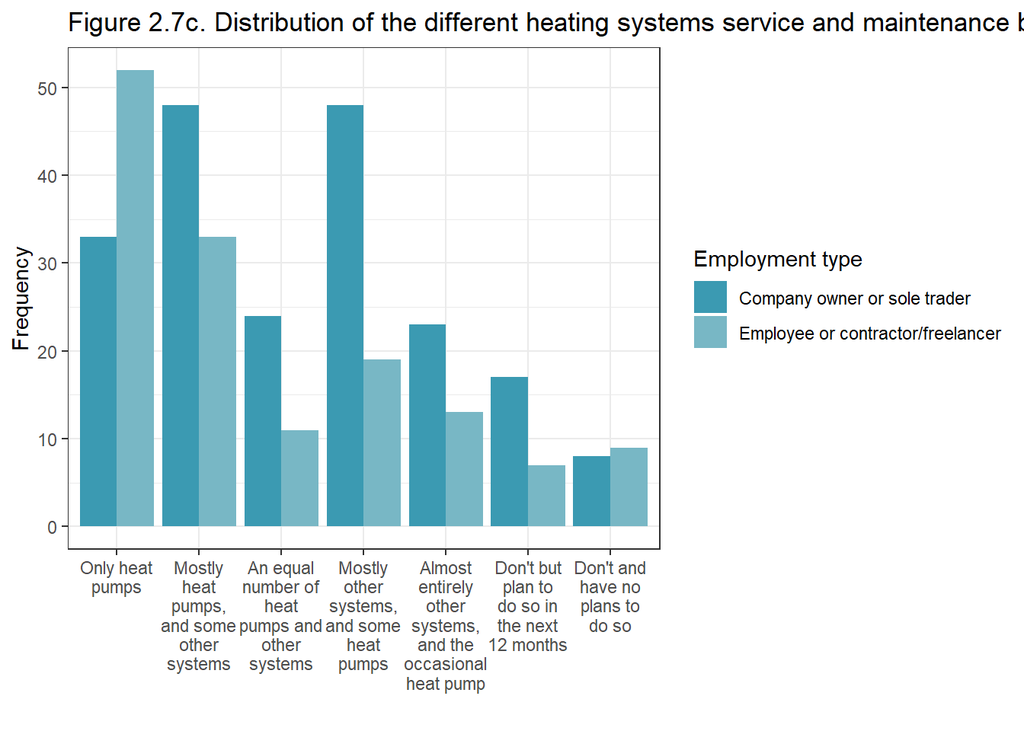

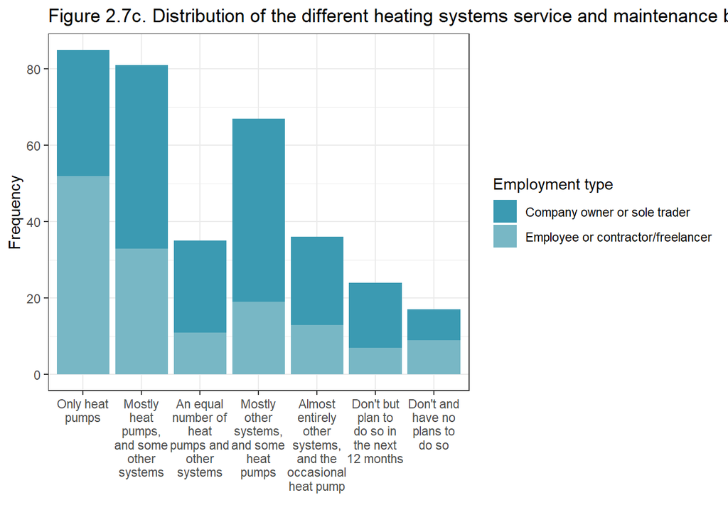

#### 2.08 | What types of heat pumps have survey participants installed over the last 12 months?

Two notes apply here. First, similarly to some questions above, different groups of installers were asked question 16 in a slightly different way to best fit their respective situations. The choices they were provided are the same. Therefore, we first merge questions 16a and 16b together to be able to have descriptive statistics for all respondents. Second, in this case, respondents were asked to select all options that apply. As a result, the unit of analysis is the option installers were presented with.

Table and Figure 2.8a show the distribution for all installers.

Table 2.8a. The types of heat pumps have survey participants installed over the last 12 months (all installers)

| Ways of working | Frequency |
| --- | --- |
| Air-source (air-to-water) heat pumps | 326 |
| Air-to-air heat pumps | 64 |
| Ground-source heat pumps | 134 |
| Hybrid air-source heat pumps | 99 |
| Hybrid ground-source heat pumps | 24 |
| Heat pumps for shared ground loops | 23 |
| Heat pumps for communal heating systems | 21 |
| Water-source heat pumps | 41 |
| Other | 13 |

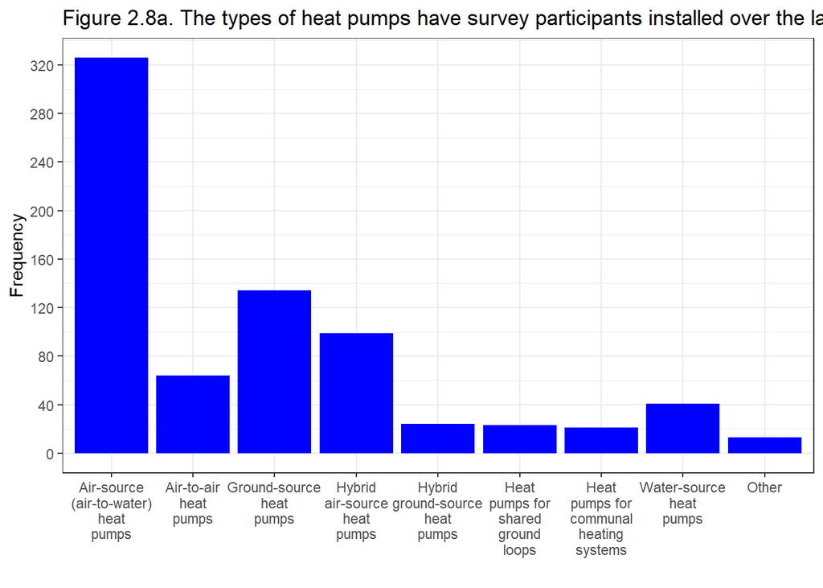

Tables and Figures 2.8b o 2.8e show the distribution for different employment type: sole traders, company owners, employees and contractors.

Table 2.8b. The types of heat pumps have survey participants installed over the last 12 months (sole traders)

| Ways of working | Frequency |
| --- | --- |
| Air-source (air-to-water) heat pumps | 35 |
| Air-to-air heat pumps | 5 |
| Ground-source heat pumps | 5 |
| Hybrid air-source heat pumps | 3 |
| Hybrid ground-source heat pumps | 0 |
| Heat pumps for shared ground loops | 0 |
| Heat pumps for communal heating systems | 0 |
| Water-source heat pumps | 0 |
| Other | 2 |

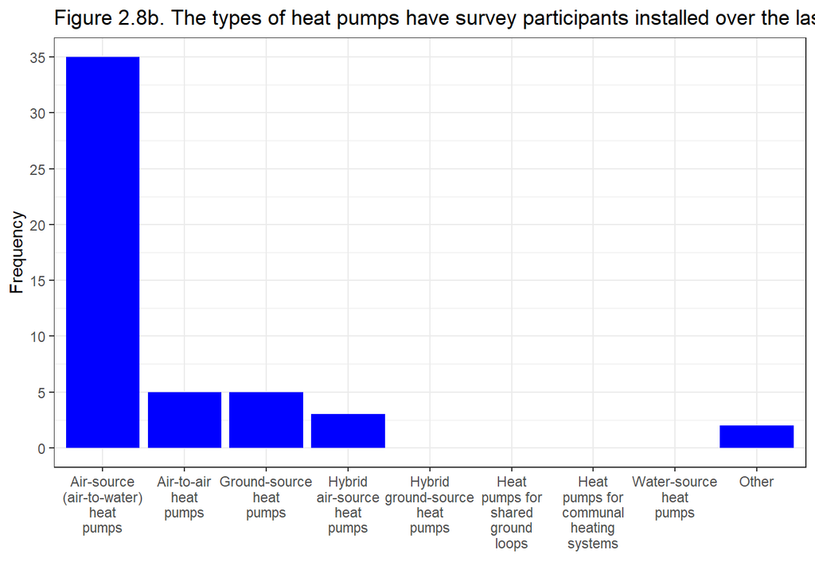

Table 2.8c. The types of heat pumps have survey participants installed over the last 12 months (company owners)

| Ways of working | Frequency |
| --- | --- |
| Air-source (air-to-water) heat pumps | 156 |
| Air-to-air heat pumps | 34 |
| Ground-source heat pumps | 74 |
| Hybrid air-source heat pumps | 47 |
| Hybrid ground-source heat pumps | 10 |
| Heat pumps for shared ground loops | 9 |
| Heat pumps for communal heating systems | 7 |
| Water-source heat pumps | 18 |
| Other | 5 |

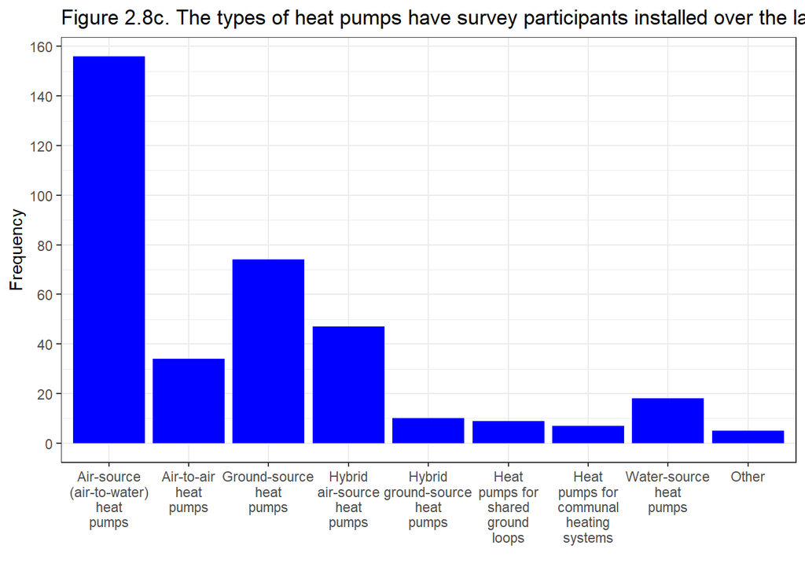

Table 2.8d. The types of heat pumps have survey participants installed over the last 12 months (employees)

| Ways of working | Frequency |
| --- | --- |
| Air-source (air-to-water) heat pumps | 105 |
| Air-to-air heat pumps | 18 |
| Ground-source heat pumps | 50 |
| Hybrid air-source heat pumps | 45 |
| Hybrid ground-source heat pumps | 12 |
| Heat pumps for shared ground loops | 12 |
| Heat pumps for communal heating systems | 13 |
| Water-source heat pumps | 21 |
| Other | 5 |

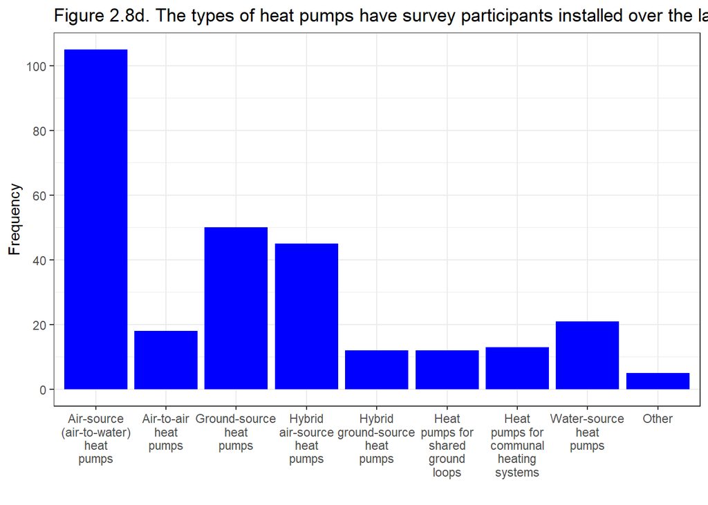

Table 2.8e. The types of heat pumps have survey participants installed over the last 12 months (contractors)

| Ways of working | Frequency |
| --- | --- |
| Air-source (air-to-water) heat pumps | 30 |
| Air-to-air heat pumps | 7 |
| Ground-source heat pumps | 5 |
| Hybrid air-source heat pumps | 4 |
| Hybrid ground-source heat pumps | 2 |
| Heat pumps for shared ground loops | 2 |
| Heat pumps for communal heating systems | 1 |
| Water-source heat pumps | 2 |
| Other | 1 |

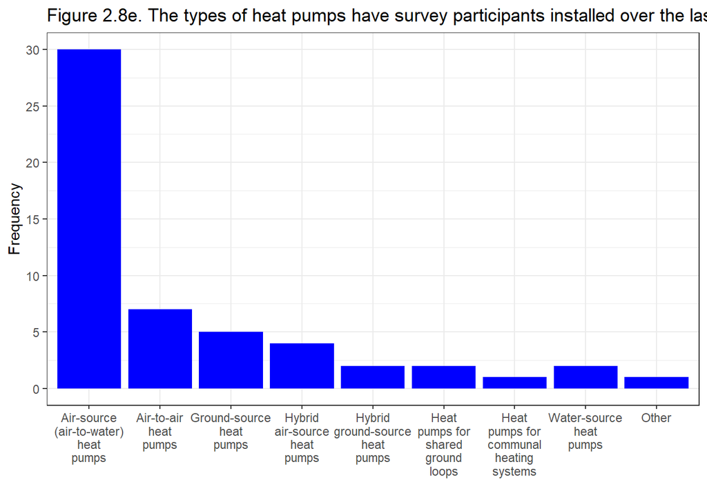